# Los Angeles Traffic Collision Data

```python
## Importing libraries
import pandas as pd
import numpy as np
import matplotlib.pyplot as plt
% matplotlib inline
import seaborn as sb
```

```python
traffic_collision = pd.read_csv('C:/Users/Lenovo/Desktop/udacity/Internship/traffic-collision-data.csv')
```

```python
df = traffic_collision.copy()
```

```python
df.head()
```

|  | DR Number | Date Reported | Date Occurred | Time Occurred | Area ID | Area Name | Reporting District | Crime Code | Crime Code Description | MO Codes | ... | Premise Description | Address | Cross Street | Location | Zip Codes | Census Tracts | Precinct Boundaries | LA Specific Plans | Council Districts | Neighborhood Councils (Certified) |
| --- | --- | --- | --- | --- | --- | --- | --- | --- | --- | --- | --- | --- | --- | --- | --- | --- | --- | --- | --- | --- | --- |
| 0 | 191010770 | 2019-06-08T00:00:00.000 | 2019-06-08T00:00:00.000 | 1216 | 10 | West Valley | 1009 | 997 | TRAFFIC COLLISION | NaN | ... | STREET | ROSCOE | HASKELL | {'human_address': '{"address": "", "city": "",... | 18914.0 | 121.0 | 426.0 | NaN | 2.0 | 88.0 |
| 1 | 190711820 | 2019-06-08T00:00:00.000 | 2019-06-08T00:00:00.000 | 1445 | 7 | Wilshire | 762 | 997 | TRAFFIC COLLISION | NaN | ... | STREET | ALFRED ST | PICO BL | {'human_address': '{"address": "", "city": "",... | 23666.0 | 641.0 | 1102.0 | NaN | 12.0 | 23.0 |
| 2 | 192011837 | 2019-06-08T00:00:00.000 | 2019-06-08T00:00:00.000 | 1245 | 20 | Olympic | 2029 | 997 | TRAFFIC COLLISION | NaN | ... | STREET | WILSHIRE | VERMONT | {'human_address': '{"address": "", "city": "",... | 22726.0 | 578.0 | 684.0 | NaN | 12.0 | 89.0 |
| 3 | 190613201 | 2019-06-08T00:00:00.000 | 2019-06-08T00:00:00.000 | 1120 | 6 | Hollywood | 645 | 997 | TRAFFIC COLLISION | NaN | ... | STREET | HOLLYWOOD BL | ORANGE DR | {'human_address': '{"address": "", "city": "",... | 23446.0 | 414.0 | 1303.0 | NaN | 8.0 | 82.0 |
| 4 | 191610033 | 2019-06-08T00:00:00.000 | 2019-06-08T00:00:00.000 | 1015 | 16 | Foothill | 1653 | 997 | TRAFFIC COLLISION | NaN | ... | STREET | ARLETA AV | BRANFORD ST | {'human_address': '{"address": "", "city": "",... | 18907.0 | 34.0 | 451.0 | NaN | 1.0 | 11.0 |

5 rows × 24 columns

```python
df['Date Reported'].max(),df['Date Reported'].min()
```

```
('2019-06-08T00:00:00.000', '2010-01-01T00:00:00.000')
```

```python
df.columns
```

```
Index(['DR Number', 'Date Reported', 'Date Occurred', 'Time Occurred',
       'Area ID', 'Area Name', 'Reporting District', 'Crime Code',
       'Crime Code Description', 'MO Codes', 'Victim Age', 'Victim Sex',
       'Victim Descent', 'Premise Code', 'Premise Description', 'Address',
       'Cross Street', 'Location', 'Zip Codes', 'Census Tracts',
       'Precinct Boundaries', 'LA Specific Plans', 'Council Districts',
       'Neighborhood Councils (Certified)'],
      dtype='object')
```

```python
list = ['Location','MO Codes','Census Tracts','Precinct Boundaries','LA Specific Plans','Council Districts','Neighborhood Councils (Certified)','Crime Code Description','Cross Street']
```

```python
df = df.drop(list,axis = 1)
```

```python
df.sample()
```

|  | DR Number | Date Reported | Date Occurred | Time Occurred | Area ID | Area Name | Reporting District | Crime Code | Victim Age | Victim Sex | Victim Descent | Premise Code | Premise Description | Address | Zip Codes |
| --- | --- | --- | --- | --- | --- | --- | --- | --- | --- | --- | --- | --- | --- | --- | --- |
| 440700 | 100416272 | 2010-10-10T00:00:00.000 | 2010-10-10T00:00:00.000 | 1725 | 4 | Hollenbeck | 464 | 997 | 56.0 | F | H | 101.0 | STREET | BREED | 23450.0 |

```python
#Converting to respective datatypes and placing Null values in empty place so that further conversion for int is easy
df['Date Reported'] = pd.to_datetime(df['Date Reported'])
df['Date Occurred'] = pd.to_datetime(df['Date Occurred'])
df['Victim Age'] = df['Victim Age'].apply(pd.to_numeric,errors = 'coerce')
df['Premise Code'] = df['Premise Code'].apply(pd.to_numeric,errors = 'coerce')
df['Zip Codes'] = df['Zip Codes'].apply(pd.to_numeric,errors = 'coerce')
```

```python
df.info()
```

```
<class 'pandas.core.frame.DataFrame'>
RangeIndex: 475227 entries, 0 to 475226
Data columns (total 15 columns):
DR Number              475227 non-null int64
Date Reported          475227 non-null datetime64[ns]
Date Occurred          475227 non-null datetime64[ns]
Time Occurred          475227 non-null int64
Area ID                475227 non-null int64
Area Name              475227 non-null object
Reporting District     475227 non-null int64
Crime Code             475227 non-null int64
Victim Age             397821 non-null float64
Victim Sex             468300 non-null object
Victim Descent         467594 non-null object
Premise Code           475202 non-null float64
Premise Description    475202 non-null object
Address                475227 non-null object
Zip Codes              474831 non-null float64
dtypes: datetime64[ns](2), float64(3), int64(5), object(5)
memory usage: 54.4+ MB
```

```python
# Problem
df['DR Number'].nunique(),sum(df['DR Number'].duplicated())
```

```
(474521, 706)
```

```python
# Code
df['DR Number'].drop_duplicates(inplace = True)
```

```python
#Check
df['DR Number'].duplicated().any(),df['DR Number'].nunique()
```

```
(False, 474521)
```

```python
#Fixing Null Values of Age,Premise Code,Zip Codes with Age mean and Mode of Premise code,Zip Code respectiveliy
df['Victim Age'] = df['Victim Age'].fillna(df['Victim Age'].mean())
df['Premise Code'] = df['Premise Code'].fillna(df['Premise Code'].mode()[0])
df['Zip Codes'] = df['Zip Codes'].fillna(df['Zip Codes'].mode()[0])
df['Victim Sex'] = df['Victim Sex'].fillna(df['Victim Sex'].mode()[0])
df['Victim Descent'] = df['Victim Descent'].fillna(df['Victim Descent'].mode()[0])
df['Premise Description'] = df['Premise Description'].fillna(df['Premise Description'].mode()[0])
```

```python
#Check
df['Victim Age'].isnull().any(),df['Premise Code'].isnull().any(),df['Zip Codes'].isnull().any()
```

```
(False, False, False)
```

```python
# Problem - Now fixing Age from Float to Age for clear Visualiztion and for better analysis
df['Victim Age'] = df['Victim Age'].astype(int)
df['Premise Code'] = df['Premise Code'].astype(int)
df['Zip Codes'] = df['Zip Codes'].astype(int)
```

```python
df.info()
```

```
<class 'pandas.core.frame.DataFrame'>
RangeIndex: 475227 entries, 0 to 475226
Data columns (total 15 columns):
DR Number              475227 non-null int64
Date Reported          475227 non-null datetime64[ns]
Date Occurred          475227 non-null datetime64[ns]
Time Occurred          475227 non-null int64
Area ID                475227 non-null int64
Area Name              475227 non-null object
Reporting District     475227 non-null int64
Crime Code             475227 non-null int64
Victim Age             475227 non-null int32
Victim Sex             475227 non-null object
Victim Descent         475227 non-null object
Premise Code           475227 non-null int32
Premise Description    475227 non-null object
Address                475227 non-null object
Zip Codes              475227 non-null int32
dtypes: datetime64[ns](2), int32(3), int64(5), object(5)
memory usage: 48.9+ MB
```

Data is now well structured to perform analysis.

# Data Analysis

### Univariate Exploratory Data Analysis

#### 1)At which time accident occurs most

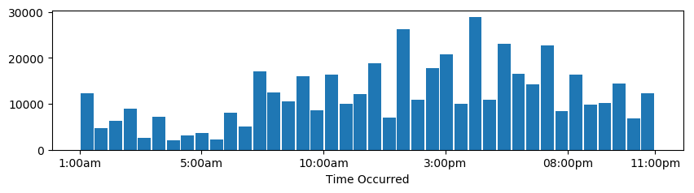

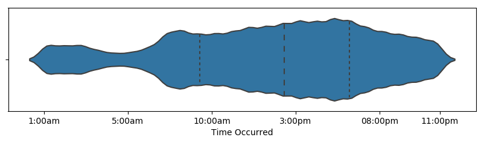

```python
from matplotlib.pyplot import figure

plt.figure(figsize=(10,5),dpi=100)
plt.subplot(2,1,1)
plt.hist(df['Time Occurred'],rwidth=0.9,bins=40)
plt.xticks([1,500,1000,1500,2000,2359],['1:00am','5:00am','10:00am','3:00pm','08:00pm','11:00pm'])
plt.xlabel("Time Occurred",fontsize = 10)
plt.show()

plt.figure(figsize=(10,5),dpi=100)
plt.subplot(2,1,2)
sb.violinplot(df['Time Occurred'],inner = 'quartile')
plt.xticks([1,500,1000,1500,2000,2359],['1:00am','5:00am','10:00am','3:00pm','08:00pm','11:00pm'])
plt.xlabel("Time Occurred",fontsize = 10)
plt.show()
```

```python
df['Time Occurred'].mean()
```

```
1354.7668629938955
```

#### 2)Area Id in which accident occurs most

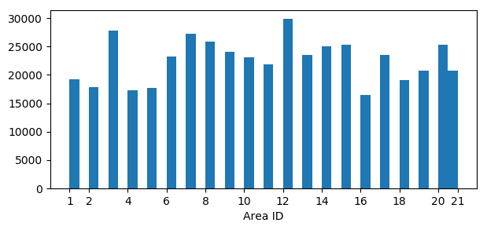

```python
plt.figure(figsize=(7,3),dpi=100)

#plotting
plt.hist(df['Area ID'],bins=40)
plt.xticks([1,2,4,6,8,10,12,14,16,18,20,21])
plt.xlabel("Area ID",fontsize = 10)
plt.show()
```

```python
df['Area ID'].value_counts(sort = True)[:3]
```

```
12    29901
3     27884
7     27306
Name: Area ID, dtype: int64
```

#### Conclusion :

- Top 3 Area ID in which accident occurs most is 12,3,7

```python
#Problem :  Since the crime code is similar for all crime commited i.e Traffic Accident delete column Crime Code
df['Crime Code'].value_counts()
```

```
997    475227
Name: Crime Code, dtype: int64
```

```python
#Code
df.drop('Crime Code',inplace = True,axis = 1)
```

```python
#Check
df.columns
```

```
Index(['DR Number', 'Date Reported', 'Date Occurred', 'Time Occurred',
       'Area ID', 'Area Name', 'Reporting District', 'Victim Age',
       'Victim Sex', 'Victim Descent', 'Premise Code', 'Premise Description',
       'Address', 'Zip Codes'],
      dtype='object')
```

#### 3)Premise Code Where Accident occured most

```python
# Premise Code Where Accident occured most
values = df['Premise Code'].value_counts().keys().tolist()
counts = df['Premise Code'].value_counts().tolist()
```

```python
# To find Area Code where Accident occured most we have to check counts  maximum and minimum counts of
# area code since the data is all about Traffic collision .
max(counts),min(counts)
```

```
(453303, 1)
```

```python
#Checking the area code of maximum code
df['Premise Code'].value_counts(sort = True)[:3]
```

```
101    453303
108     15396
102      2374
Name: Premise Code, dtype: int64
```

#### Conclusion:

- Top 3 Premise Code in which accident occurs most is 101,108,102

#### 4)Top Reporting District

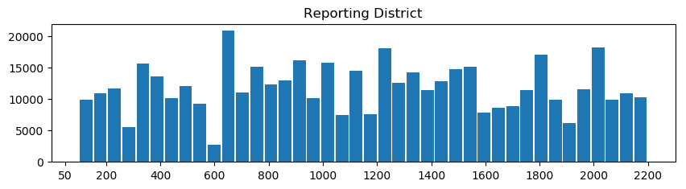

```python
plt.figure(figsize=(10,5),dpi=100)
plt.subplot(2,1,1)
plt.hist(df['Reporting District'],rwidth=0.9,bins=40)
plt.xticks([50,200,400,600,800,1000,1200,1400,1600,1800,2000,2200],['50','200','400','600','800','1000','1200','1400','1600','1800','2000','2200'])
plt.title("Reporting District");
plt.show()
```

#### Conclusion

- Reporting District - 645 has Maximum Reporting having count 2260. #### More Detail about the district 645.

[figure not shown]

  #### Location of Reporting District 645 In Los Angelos

[figure not shown]

#### Refrence : http://geohub.lacity.org/datasets/lapd-reporting-districts/data?geometry=-119.056%2C33.773%2C-116.938%2C34.568

### 5)Who are the most victims whether Males or Females?

- Note: X- Uknown

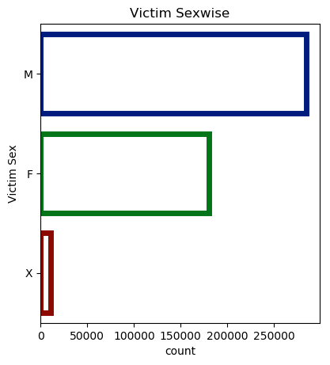

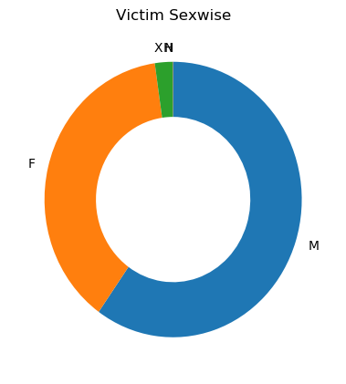

```python
#Visualization

#plotting

plt.figure(figsize=(10,5),dpi=100)
plt.subplot(1,2,1)
sb.countplot(y = df['Victim Sex'],facecolor=(0, 0, 0, 0),linewidth=5,edgecolor=sb.color_palette("dark", 5),order = df['Victim Sex'].value_counts().index[:3])
plt.title("Victim Sexwise");

plt.figure(figsize=(10,5),dpi=100)
plt.subplot(1,2,2)
sorted_counts = df['Victim Sex'].value_counts()
plt.pie(sorted_counts,labels = sorted_counts.index ,startangle = 90 , counterclock = False , wedgeprops ={'width' : 0.4});
plt.title("Victim Sexwise");
```

#### Conclusion :

- Most victim were male and then females.

#### 6)Victim Descent

- A - Other Asian ,B - Black, C - Chinese ,D - Cambodian ,F - Filipino, G - Guamanian ,H - Hispanic/Latin/Mexican, I - American Indian/Alaskan Native, J - Japanese ,K - Korean ,L - Laotian, O - Other ,P - Pacific Islander, S - Samoan, U - Hawaiian, V - Vietnamese, W - White, X - Unknown, Z - Asian Indian

```python
df['Victim Descent'].value_counts() * 100 / df.shape[0]
```

```
H    38.408592
W    23.876169
O    14.895408
B    13.045134
X     4.490275
A     3.757783
K     0.806562
F     0.293965
C     0.144352
U     0.073649
J     0.056815
V     0.038297
P     0.037877
I     0.030091
Z     0.025882
G     0.008207
S     0.006523
D     0.003156
L     0.000842
-     0.000421
Name: Victim Descent, dtype: float64
```

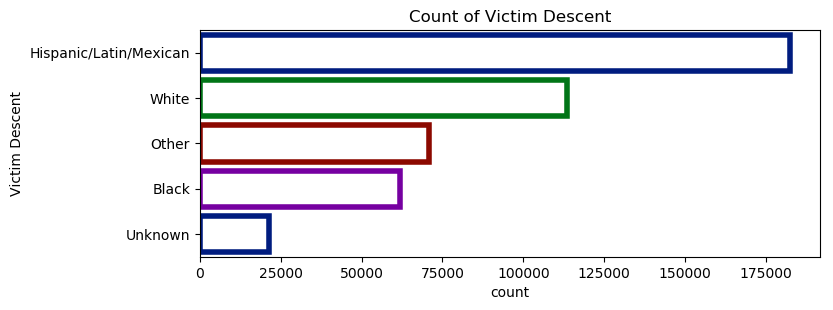

```python
#Visualization for V
plt.figure(figsize=(8,3),dpi=100)

#plotting
ax = sb.countplot(y = df['Victim Descent'],facecolor=(0, 0, 0, 0),linewidth=4,edgecolor=sb.color_palette("dark", 4), order = df['Victim Descent'].value_counts().index[:5])
labels = ['Hispanic/Latin/Mexican','White','Other','Black','Unknown']
ax.set_yticklabels(labels)
plt.title("Count of Victim Descent");
plt.show()
```

#### Conclusions:

- Top Victim Descent which more effected are Hispanic/Latin/Mexican,White,Other,Black,Unknown.

#### 7)Zip Codes of cities which has max and min Traffic Accident

```python
df['Zip Codes'].value_counts(sort = True)[:5]
```

```
23675    10577
23668    10114
22727    10080
23446     9974
22352     9934
Name: Zip Codes, dtype: int64
```

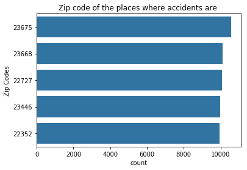

```python
base_color = sb.color_palette()[0]
sb.countplot(y= df['Zip Codes'],color = base_color, order = df['Zip Codes'].value_counts().index[:5])
plt.title("Zip code of the places where accidents are ");
```

#### 8)Top Premise Description were accident occurred most

```python
#Top Traffic Accident Premise Description
df['Premise Description'].value_counts()[:5] * 100 / df['Premise Description'].shape[0]
```

```
STREET         95.386626
PARKING LOT     3.239715
SIDEWALK        0.499551
ALLEY           0.173601
DRIVEWAY        0.169182
Name: Premise Description, dtype: float64
```

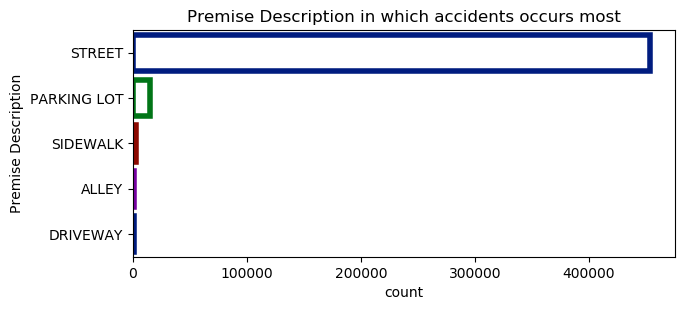

```python
#Visualization for Top Traffic Accident Premise Description
plt.figure(figsize=(7,3),dpi=100)

#plotting
ax = sb.countplot(y= df['Premise Description'],facecolor=(0, 0, 0, 0),linewidth=4,edgecolor=sb.color_palette("dark", 4), order = df['Premise Description'].value_counts().index[:5])
plt.title("Premise Description in which accidents occurs most")
plt.show()
```

#### Conclusions :

- Top Premises were accident occurs most are Street,Parking Lot,Sidewalk,Alley and in Driveway

#### 9) Year in which accident occured most?

- Note : In the year 2019 record is uptil 08-june-2019

```
Text(0.5,1,'Yearwise Traffic Accidents')
```

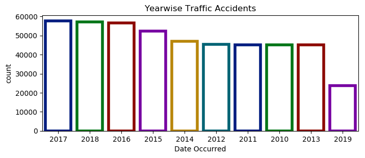

```python
plt.figure(figsize=(8,3),dpi=100)

#plotting
ax = sb.countplot( df['Date Occurred'].dt.year,facecolor=(0, 0, 0, 0),linewidth=4,edgecolor=sb.color_palette("dark", 10), order = df['Date Occurred'].dt.year.value_counts().index[:])
plt.title("Yearwise Traffic Accidents")
```

#### Conclusion :

- In the year 2017 and 2018 there where maximum accidents

#### 10) In which month accident occured more ?

```
Text(0.5,1,'Count of Month in which accident occured')
```

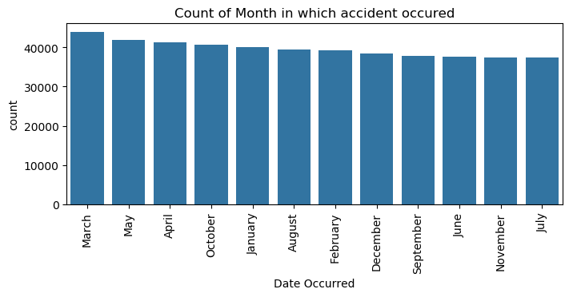

```python
plt.figure(figsize=(8,3),dpi=100)

#plotting
base_color = sb.color_palette()[0]
ax = sb.countplot( df['Date Occurred'].dt.month,color = base_color, order = df['Date Occurred'].dt.month.value_counts().index[:])
plt.xticks([0,1,2,3,4,5,6,7,8,9,10,11],['March','May','April','October','January','August','February','December','September','June','November','July'],rotation = 90);
plt.title("Count of Month in which accident occured")
```

#### Conclusion :

- March,May,April are the month in which accident occure most

## Bivariate Exploratory Data Analysis

#### 11) Victim Age vs Victim Sex

```
Text(0.5,1,'Victim Sex Vs Victim Age')
```

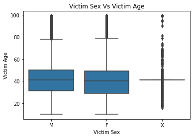

```python
# Victim Sex Vs Vicim Age
base_color = sb.color_palette()[0]
sb.boxplot(data = df , x = "Victim Sex" , y ="Victim Age" , color = base_color,order = df['Victim Sex'].value_counts().index[:3]);
plt.title('Victim Sex Vs Victim Age')
```

#### Conclusion :

- Male which had accident have mean of age 42 years while female which had accident have mean age of 40years

```python
df[df['Victim Sex'] == "F"]['Victim Age'].mean()
```

```
40.49360636531724
```

#### 12)Victim Descent Vs Victiim Age

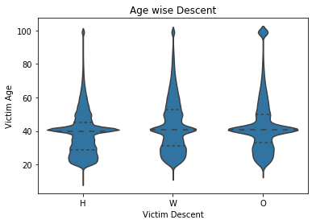

```python
base_color = sb.color_palette()[0]
sb.violinplot(data = df , x = "Victim Descent" , y ="Victim Age" , color = base_color,order = df['Victim Descent'].value_counts().index[:3],inner = "quartile");
plt.title("Age wise Descent");
```

```python
df[df['Victim Descent'] == 'H']['Victim Age'].mean(),df[df['Victim Descent'] == 'W']['Victim Age'].mean(),df[df['Victim Descent'] == 'O']['Victim Age'].mean()
```

```
(38.99149171633941, 43.2626513669293, 43.84782516563776)
```

#### Conclusion

- Victim Descent - H have mean age pf 39, W has mean age of 43,O has mean age of 44